# Data Preparation, Partitioning, & Visualization

Alex Wolff

2024-04-13

## Load Packages

```r
library(tidyverse)
library(kableExtra)
library(recipes)
library(rsample)
library(reshape2)
options(scipen=999)
```

# Part 1 - New York City Flight Data

## Load Data 1

```r
library(nycflights13)
```

## Question 1

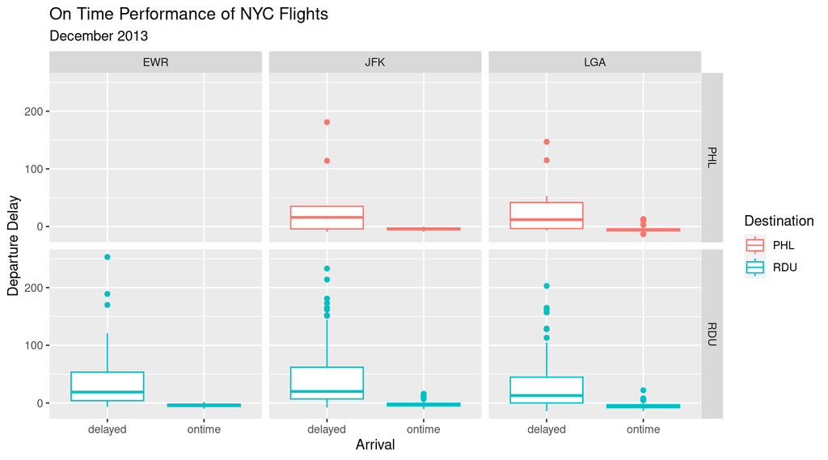

```r
flights %>%
  mutate(arrival = if_else(arr_delay > 0, "delayed", "ontime")) %>%
  filter(dest %in% c("PHL", "RDU"),
         month == 12) %>%
  na.omit() %>%
  ggplot() +
    geom_boxplot(aes(x = arrival, y = dep_delay, color = dest)) +
    facet_grid(dest ~ origin) +
    labs(title = "On Time Performance of NYC Flights",
         subtitle = "December 2013",
         x = "Arrival",
         y = "Departure Delay",
         color = "Destination")
```

## Question 2

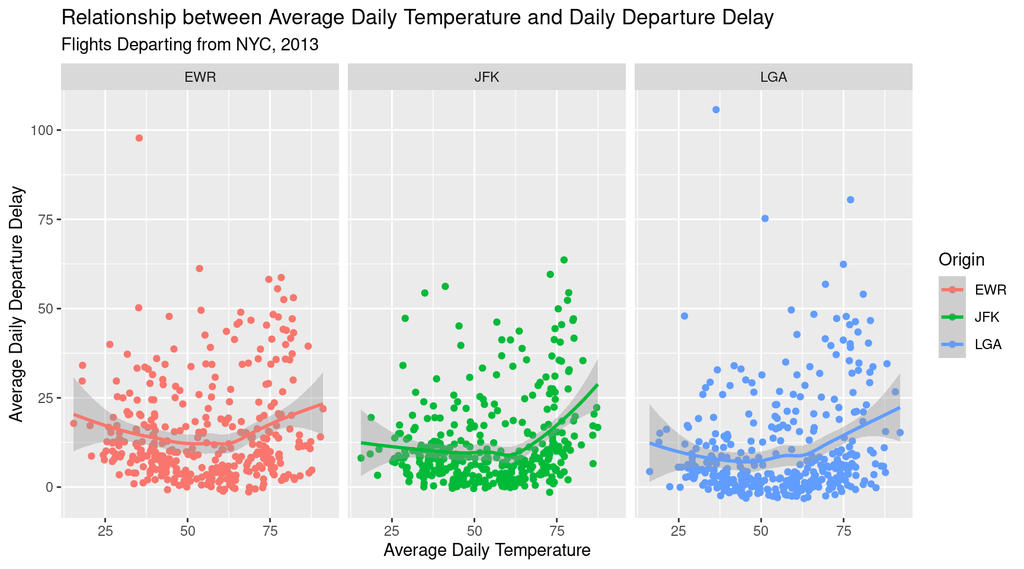

```r
flights %>%
  left_join(weather, by = c("year", "month", "day", "origin")) %>%
  group_by(year, month, day, origin) %>%
  summarize(
    avg_daily_dep_delay = mean(dep_delay, na.rm = TRUE),
    avg_daily_temp = mean(temp, na.rm = TRUE)) %>%
  ggplot(aes(x = avg_daily_temp, y = avg_daily_dep_delay, color = origin)) +
    geom_point() +
    geom_smooth() +
    facet_wrap(~ origin)+
    labs(title = "Relationship between Average Daily Temperature and Daily Departure Delay",
         subtitle = "Flights Departing from NYC, 2013",
         x = "Average Daily Temperature",
         y = "Average Daily Departure Delay",
         color = "Origin")
```

# Part 2 - Bike Rentals in Washington, DC

## Load Data 2

```r
bike_data <- read_csv("/home/ballengerb@ad.wlu.edu/BUS_317_01/wolffa24/Data/bike_share_day.csv")
```

## Question 3

```r
bike_data <- bike_data %>%
  rename(index=instant,
         date = dteday,
         year = yr,
         month = mnth,
         ftemp = atemp,
         humidity = hum,
         casual_cnt = casual,
         registered_cnt = registered,
         total_count = cnt) %>%
  mutate(
    season = factor(season,
                    levels = c(2, 3, 4, 1),
                    labels = c("Spring", "Summer", "Fall", "Winter")),
    holiday = factor(holiday,
                     levels = c(0, 1),
                     labels = c("no",
                                "yes")),
    workingday = factor(workingday,
                        levels = c(0, 1),
                        labels = c("no",
                                   "yes")),
    year = factor(year,
                  levels = c(0, 1),
                  labels = c("2011",
                             "2012")),
    weathersit = factor(weathersit,
                        levels = c(1, 2, 3, 4),
                        labels = c("clear",
                                   "mist",
                                   "light precipitation",
                                   "heavy precipitation")),
    raw_temp = temp * 41,
    raw_ftemp = ftemp * 50,
    raw_humidity = humidity * 100,
    raw_windsped = windspeed * 67)

bike_data %>%
  head(50) %>%
  kable() %>%
  kable_styling() %>%
  scroll_box(width = "100%", height = "400px")
```

| index | date | season | year | month | holiday | weekday | workingday | weathersit | temp | ftemp | humidity | windspeed | casual_cnt | registered_cnt | total_count | raw_temp | raw_ftemp | raw_humidity | raw_windsped |
| --- | --- | --- | --- | --- | --- | --- | --- | --- | --- | --- | --- | --- | --- | --- | --- | --- | --- | --- | --- |
| 1 | 1/1/11 | Winter | 2011 | 1 | no | 6 | no | mist | 0.3441670 | 0.3636250 | 0.805833 | 0.1604460 | 331 | 654 | 985 | 14.110847 | 18.181250 | 80.5833 | 10.749882 |
| 2 | 1/2/11 | Winter | 2011 | 1 | no | 0 | no | mist | 0.3634780 | 0.3537390 | 0.696087 | 0.2485390 | 131 | 670 | 801 | 14.902598 | 17.686950 | 69.6087 | 16.652113 |
| 3 | 1/3/11 | Winter | 2011 | 1 | no | 1 | yes | clear | 0.1963640 | 0.1894050 | 0.437273 | 0.2483090 | 120 | 1229 | 1349 | 8.050924 | 9.470250 | 43.7273 | 16.636703 |
| 4 | 1/4/11 | Winter | 2011 | 1 | no | 2 | yes | clear | 0.2000000 | 0.2121220 | 0.590435 | 0.1602960 | 108 | 1454 | 1562 | 8.200000 | 10.606100 | 59.0435 | 10.739832 |
| 5 | 1/5/11 | Winter | 2011 | 1 | no | 3 | yes | clear | 0.2269570 | 0.2292700 | 0.436957 | 0.1869000 | 82 | 1518 | 1600 | 9.305237 | 11.463500 | 43.6957 | 12.522300 |
| 6 | 1/6/11 | Winter | 2011 | 1 | no | 4 | yes | clear | 0.2043480 | 0.2332090 | 0.518261 | 0.0895652 | 88 | 1518 | 1606 | 8.378268 | 11.660450 | 51.8261 | 6.000868 |
| 7 | 1/7/11 | Winter | 2011 | 1 | no | 5 | yes | mist | 0.1965220 | 0.2088390 | 0.498696 | 0.1687260 | 148 | 1362 | 1510 | 8.057402 | 10.441950 | 49.8696 | 11.304642 |
| 8 | 1/8/11 | Winter | 2011 | 1 | no | 6 | no | mist | 0.1650000 | 0.1622540 | 0.535833 | 0.2668040 | 68 | 891 | 959 | 6.765000 | 8.112700 | 53.5833 | 17.875868 |
| 9 | 1/9/11 | Winter | 2011 | 1 | no | 0 | no | clear | 0.1383330 | 0.1161750 | 0.434167 | 0.3619500 | 54 | 768 | 822 | 5.671653 | 5.808750 | 43.4167 | 24.250650 |
| 10 | 1/10/11 | Winter | 2011 | 1 | no | 1 | yes | clear | 0.1508330 | 0.1508880 | 0.482917 | 0.2232670 | 41 | 1280 | 1321 | 6.184153 | 7.544400 | 48.2917 | 14.958889 |
| 11 | 1/11/11 | Winter | 2011 | 1 | no | 2 | yes | mist | 0.1690910 | 0.1914640 | 0.686364 | 0.1221320 | 43 | 1220 | 1263 | 6.932731 | 9.573200 | 68.6364 | 8.182844 |
| 12 | 1/12/11 | Winter | 2011 | 1 | no | 3 | yes | clear | 0.1727270 | 0.1604730 | 0.599545 | 0.3046270 | 25 | 1137 | 1162 | 7.081807 | 8.023650 | 59.9545 | 20.410009 |
| 13 | 1/13/11 | Winter | 2011 | 1 | no | 4 | yes | clear | 0.1650000 | 0.1508830 | 0.470417 | 0.3010000 | 38 | 1368 | 1406 | 6.765000 | 7.544150 | 47.0417 | 20.167000 |
| 14 | 1/14/11 | Winter | 2011 | 1 | no | 5 | yes | clear | 0.1608700 | 0.1884130 | 0.537826 | 0.1265480 | 54 | 1367 | 1421 | 6.595670 | 9.420650 | 53.7826 | 8.478716 |
| 15 | 1/15/11 | Winter | 2011 | 1 | no | 6 | no | mist | 0.2333330 | 0.2481120 | 0.498750 | 0.1579630 | 222 | 1026 | 1248 | 9.566653 | 12.405600 | 49.8750 | 10.583521 |
| 16 | 1/16/11 | Winter | 2011 | 1 | no | 0 | no | clear | 0.2316670 | 0.2342170 | 0.483750 | 0.1884330 | 251 | 953 | 1204 | 9.498347 | 11.710850 | 48.3750 | 12.625011 |
| 17 | 1/17/11 | Winter | 2011 | 1 | yes | 1 | no | mist | 0.1758330 | 0.1767710 | 0.537500 | 0.1940170 | 117 | 883 | 1000 | 7.209153 | 8.838550 | 53.7500 | 12.999139 |
| 18 | 1/18/11 | Winter | 2011 | 1 | no | 2 | yes | mist | 0.2166670 | 0.2323330 | 0.861667 | 0.1467750 | 9 | 674 | 683 | 8.883347 | 11.616650 | 86.1667 | 9.833925 |
| 19 | 1/19/11 | Winter | 2011 | 1 | no | 3 | yes | mist | 0.2921740 | 0.2984220 | 0.741739 | 0.2083170 | 78 | 1572 | 1650 | 11.979134 | 14.921100 | 74.1739 | 13.957239 |
| 20 | 1/20/11 | Winter | 2011 | 1 | no | 4 | yes | mist | 0.2616670 | 0.2550500 | 0.538333 | 0.1959040 | 83 | 1844 | 1927 | 10.728347 | 12.752500 | 53.8333 | 13.125568 |
| 21 | 1/21/11 | Winter | 2011 | 1 | no | 5 | yes | clear | 0.1775000 | 0.1578330 | 0.457083 | 0.3532420 | 75 | 1468 | 1543 | 7.277500 | 7.891650 | 45.7083 | 23.667214 |
| 22 | 1/22/11 | Winter | 2011 | 1 | no | 6 | no | clear | 0.0591304 | 0.0790696 | 0.400000 | 0.1719700 | 93 | 888 | 981 | 2.424346 | 3.953480 | 40.0000 | 11.521990 |
| 23 | 1/23/11 | Winter | 2011 | 1 | no | 0 | no | clear | 0.0965217 | 0.0988391 | 0.436522 | 0.2466000 | 150 | 836 | 986 | 3.957390 | 4.941955 | 43.6522 | 16.522200 |
| 24 | 1/24/11 | Winter | 2011 | 1 | no | 1 | yes | clear | 0.0973913 | 0.1179300 | 0.491739 | 0.1583300 | 86 | 1330 | 1416 | 3.993043 | 5.896500 | 49.1739 | 10.608110 |
| 25 | 1/25/11 | Winter | 2011 | 1 | no | 2 | yes | mist | 0.2234780 | 0.2345260 | 0.616957 | 0.1297960 | 186 | 1799 | 1985 | 9.162598 | 11.726300 | 61.6957 | 8.696332 |
| 26 | 1/26/11 | Winter | 2011 | 1 | no | 3 | yes | light precipitation | 0.2175000 | 0.2036000 | 0.862500 | 0.2938500 | 34 | 472 | 506 | 8.917500 | 10.180000 | 86.2500 | 19.687950 |
| 27 | 1/27/11 | Winter | 2011 | 1 | no | 4 | yes | clear | 0.1950000 | 0.2197000 | 0.687500 | 0.1138370 | 15 | 416 | 431 | 7.995000 | 10.985000 | 68.7500 | 7.627079 |
| 28 | 1/28/11 | Winter | 2011 | 1 | no | 5 | yes | mist | 0.2034780 | 0.2233170 | 0.793043 | 0.1233000 | 38 | 1129 | 1167 | 8.342598 | 11.165850 | 79.3043 | 8.261100 |
| 29 | 1/29/11 | Winter | 2011 | 1 | no | 6 | no | clear | 0.1965220 | 0.2121260 | 0.651739 | 0.1453650 | 123 | 975 | 1098 | 8.057402 | 10.606300 | 65.1739 | 9.739455 |
| 30 | 1/30/11 | Winter | 2011 | 1 | no | 0 | no | clear | 0.2165220 | 0.2503220 | 0.722174 | 0.0739826 | 140 | 956 | 1096 | 8.877402 | 12.516100 | 72.2174 | 4.956834 |
| 31 | 1/31/11 | Winter | 2011 | 1 | no | 1 | yes | mist | 0.1808330 | 0.1862500 | 0.603750 | 0.1871920 | 42 | 1459 | 1501 | 7.414153 | 9.312500 | 60.3750 | 12.541864 |
| 32 | 2/1/11 | Winter | 2011 | 2 | no | 2 | yes | mist | 0.1921740 | 0.2345300 | 0.829565 | 0.0532130 | 47 | 1313 | 1360 | 7.879134 | 11.726500 | 82.9565 | 3.565271 |
| 33 | 2/2/11 | Winter | 2011 | 2 | no | 3 | yes | mist | 0.2600000 | 0.2544170 | 0.775417 | 0.2643080 | 72 | 1454 | 1526 | 10.660000 | 12.720850 | 77.5417 | 17.708636 |
| 34 | 2/3/11 | Winter | 2011 | 2 | no | 4 | yes | clear | 0.1869570 | 0.1778780 | 0.437826 | 0.2777520 | 61 | 1489 | 1550 | 7.665237 | 8.893900 | 43.7826 | 18.609384 |
| 35 | 2/4/11 | Winter | 2011 | 2 | no | 5 | yes | mist | 0.2113040 | 0.2285870 | 0.585217 | 0.1278390 | 88 | 1620 | 1708 | 8.663464 | 11.429350 | 58.5217 | 8.565213 |
| 36 | 2/5/11 | Winter | 2011 | 2 | no | 6 | no | mist | 0.2333330 | 0.2430580 | 0.929167 | 0.1610790 | 100 | 905 | 1005 | 9.566653 | 12.152900 | 92.9167 | 10.792293 |
| 37 | 2/6/11 | Winter | 2011 | 2 | no | 0 | no | clear | 0.2858330 | 0.2916710 | 0.568333 | 0.1418000 | 354 | 1269 | 1623 | 11.719153 | 14.583550 | 56.8333 | 9.500600 |
| 38 | 2/7/11 | Winter | 2011 | 2 | no | 1 | yes | clear | 0.2716670 | 0.3036580 | 0.738333 | 0.0454083 | 120 | 1592 | 1712 | 11.138347 | 15.182900 | 73.8333 | 3.042356 |
| 39 | 2/8/11 | Winter | 2011 | 2 | no | 2 | yes | clear | 0.2208330 | 0.1982460 | 0.537917 | 0.3619500 | 64 | 1466 | 1530 | 9.054153 | 9.912300 | 53.7917 | 24.250650 |
| 40 | 2/9/11 | Winter | 2011 | 2 | no | 3 | yes | mist | 0.1347830 | 0.1442830 | 0.494783 | 0.1888390 | 53 | 1552 | 1605 | 5.526103 | 7.214150 | 49.4783 | 12.652213 |
| 41 | 2/10/11 | Winter | 2011 | 2 | no | 4 | yes | clear | 0.1443480 | 0.1495480 | 0.437391 | 0.2219350 | 47 | 1491 | 1538 | 5.918268 | 7.477400 | 43.7391 | 14.869645 |
| 42 | 2/11/11 | Winter | 2011 | 2 | no | 5 | yes | clear | 0.1890910 | 0.2135090 | 0.506364 | 0.1085500 | 149 | 1597 | 1746 | 7.752731 | 10.675450 | 50.6364 | 7.272850 |
| 43 | 2/12/11 | Winter | 2011 | 2 | no | 6 | no | clear | 0.2225000 | 0.2329540 | 0.544167 | 0.2033670 | 288 | 1184 | 1472 | 9.122500 | 11.647700 | 54.4167 | 13.625589 |
| 44 | 2/13/11 | Winter | 2011 | 2 | no | 0 | no | clear | 0.3165220 | 0.3241130 | 0.457391 | 0.2608830 | 397 | 1192 | 1589 | 12.977402 | 16.205650 | 45.7391 | 17.479161 |
| 45 | 2/14/11 | Winter | 2011 | 2 | no | 1 | yes | clear | 0.4150000 | 0.3983500 | 0.375833 | 0.4179080 | 208 | 1705 | 1913 | 17.015000 | 19.917500 | 37.5833 | 27.999836 |
| 46 | 2/15/11 | Winter | 2011 | 2 | no | 2 | yes | clear | 0.2660870 | 0.2542740 | 0.314348 | 0.2913740 | 140 | 1675 | 1815 | 10.909567 | 12.713700 | 31.4348 | 19.522058 |
| 47 | 2/16/11 | Winter | 2011 | 2 | no | 3 | yes | clear | 0.3182610 | 0.3162000 | 0.423478 | 0.2517910 | 218 | 1897 | 2115 | 13.048701 | 15.810000 | 42.3478 | 16.869997 |
| 48 | 2/17/11 | Winter | 2011 | 2 | no | 4 | yes | clear | 0.4358330 | 0.4286580 | 0.505000 | 0.2301040 | 259 | 2216 | 2475 | 17.869153 | 21.432900 | 50.5000 | 15.416968 |
| 49 | 2/18/11 | Winter | 2011 | 2 | no | 5 | yes | clear | 0.5216670 | 0.5119830 | 0.516667 | 0.2649250 | 579 | 2348 | 2927 | 21.388347 | 25.599150 | 51.6667 | 17.749975 |
| 50 | 2/19/11 | Winter | 2011 | 2 | no | 6 | no | clear | 0.3991670 | 0.3914040 | 0.187917 | 0.5074630 | 532 | 1103 | 1635 | 16.365847 | 19.570200 | 18.7917 | 34.000021 |

## Question 4

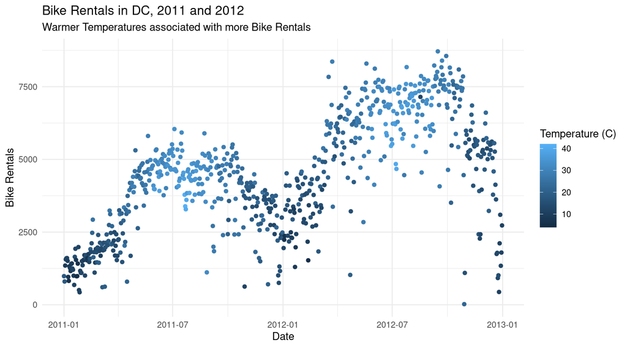

```r
bike_data %>%
  mutate(date = as.Date(date, format = "%m/%d/%y")) %>%
  ggplot(aes(x = date, y = total_count, color = raw_ftemp)) +
  geom_point() +
  scale_x_date(
    date_breaks = "6 months",
    date_labels = "%Y-%m",) +
  xlim(as.Date("2011-01-01"), as.Date("2012-12-31")) +
  theme_minimal() +
  labs(
    title = "Bike Rentals in DC, 2011 and 2012",
    subtitle = "Warmer Temperatures associated with more Bike Rentals",
    x = "Date",
    y = "Bike Rentals",
    color = "Temperature (C)")
```

The graph above shows the number of bike rentals in Washington DC from 2011 to 2012. The x-axis is dated sequentially to show the relationship between bike rentals during different parts of the year. Furthermore, the graph is colored by the average daily temperature. The graph shows two clear spikes in bike rentals during the middle months of the year—May, June, July, and August—for both 2011 and 2012. These spikes in bike rentals are also supported by higher average daily temperatures. Therefore, this graph suggests that the warmer temperatures, during the middle months of the year, are associated with more bike rentals.

## Question 5

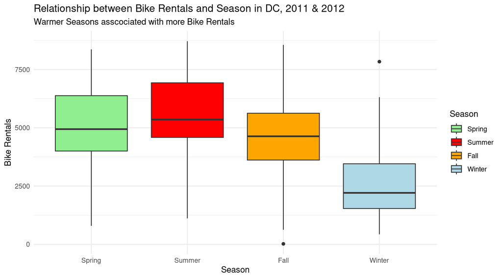

```r
bike_data %>%
  ggplot(aes(x = season, y = total_count, fill = season)) +
  geom_boxplot() +
  scale_fill_manual(values = c("Fall" = "orange",
                               "Winter" = "lightblue",
                               "Spring" = "lightgreen",
                               "Summer" = "red")) +
  theme_minimal() +
  labs(title = "Relationship between Bike Rentals and Season in DC, 2011 & 2012",
       subtitle = "Warmer Seasons asscociated with more Bike Rentals",
       x = "Season", y = "Bike Rentals", fill = "Season")
```

The graph above displays the distribution of bike rentals for each season. Similarly to the graph in question 4, there is a spike in the median number of bike rentals during the spring and summer which falls off towards the fall and winter. These results support the conclusions from question 4 which suggests that warmer weather, found in spring and summer months, increase the number of bike rentals.

## Question 6

```r
bike_data <- bike_data %>%
  mutate(id = row_number())

set.seed(2022)

training_bike_data <- bike_data %>%
  slice_sample(prop = .75)

validation_bike_data <- bike_data %>%
  anti_join(training_bike_data, by = 'id')

training_bike_data %>%
    head(10) %>%
    kable() %>%
    kable_styling() %>%
    scroll_box(width = "100%", height = "400px")
```

| index | date | season | year | month | holiday | weekday | workingday | weathersit | temp | ftemp | humidity | windspeed | casual_cnt | registered_cnt | total_count | raw_temp | raw_ftemp | raw_humidity | raw_windsped | id |
| --- | --- | --- | --- | --- | --- | --- | --- | --- | --- | --- | --- | --- | --- | --- | --- | --- | --- | --- | --- | --- |
| 228 | 8/16/11 | Summer | 2011 | 8 | no | 2 | yes | clear | 0.700833 | 0.645837 | 0.578333 | 0.2363290 | 721 | 4004 | 4725 | 28.73415 | 32.29185 | 57.8333 | 15.834043 | 228 |
| 435 | 3/10/12 | Winter | 2012 | 3 | no | 6 | no | clear | 0.287500 | 0.277767 | 0.350417 | 0.2257500 | 968 | 3150 | 4118 | 11.78750 | 13.88835 | 35.0417 | 15.125250 | 435 |
| 718 | 12/18/12 | Fall | 2012 | 12 | no | 2 | yes | clear | 0.410833 | 0.409708 | 0.666250 | 0.2214040 | 433 | 5124 | 5557 | 16.84415 | 20.48540 | 66.6250 | 14.834068 | 718 |
| 708 | 12/8/12 | Fall | 2012 | 12 | no | 6 | no | mist | 0.381667 | 0.389508 | 0.911250 | 0.1013790 | 1153 | 4429 | 5582 | 15.64835 | 19.47540 | 91.1250 | 6.792393 | 708 |
| 703 | 12/3/12 | Fall | 2012 | 12 | no | 1 | yes | clear | 0.452500 | 0.455796 | 0.767500 | 0.0827208 | 555 | 5679 | 6234 | 18.55250 | 22.78980 | 76.7500 | 5.542294 | 703 |
| 729 | 12/29/12 | Winter | 2012 | 12 | no | 6 | no | mist | 0.253333 | 0.242400 | 0.752917 | 0.1243830 | 159 | 1182 | 1341 | 10.38665 | 12.12000 | 75.2917 | 8.333661 | 729 |
| 476 | 4/20/12 | Spring | 2012 | 4 | no | 5 | yes | clear | 0.526667 | 0.515775 | 0.694583 | 0.1498710 | 1340 | 5950 | 7290 | 21.59335 | 25.78875 | 69.4583 | 10.041357 | 476 |
| 123 | 5/3/11 | Spring | 2011 | 5 | no | 2 | yes | mist | 0.616667 | 0.582079 | 0.697083 | 0.3426670 | 603 | 3848 | 4451 | 25.28335 | 29.10395 | 69.7083 | 22.958689 | 123 |
| 233 | 8/21/11 | Summer | 2011 | 8 | no | 0 | no | clear | 0.710833 | 0.675525 | 0.770000 | 0.2487540 | 1249 | 2624 | 3873 | 29.14415 | 33.77625 | 77.0000 | 16.666518 | 233 |
| 270 | 9/27/11 | Fall | 2011 | 9 | no | 2 | yes | mist | 0.636667 | 0.574525 | 0.885417 | 0.1181710 | 477 | 3643 | 4120 | 26.10335 | 28.72625 | 88.5417 | 7.917457 | 270 |

```r
validation_bike_data %>%
    head(10) %>%
    kable() %>%
    kable_styling() %>%
    scroll_box(width = "100%", height = "400px")
```

| index | date | season | year | month | holiday | weekday | workingday | weathersit | temp | ftemp | humidity | windspeed | casual_cnt | registered_cnt | total_count | raw_temp | raw_ftemp | raw_humidity | raw_windsped | id |
| --- | --- | --- | --- | --- | --- | --- | --- | --- | --- | --- | --- | --- | --- | --- | --- | --- | --- | --- | --- | --- |
| 2 | 1/2/11 | Winter | 2011 | 1 | no | 0 | no | mist | 0.363478 | 0.353739 | 0.696087 | 0.248539 | 131 | 670 | 801 | 14.902598 | 17.68695 | 69.6087 | 16.652113 | 2 |
| 4 | 1/4/11 | Winter | 2011 | 1 | no | 2 | yes | clear | 0.200000 | 0.212122 | 0.590435 | 0.160296 | 108 | 1454 | 1562 | 8.200000 | 10.60610 | 59.0435 | 10.739832 | 4 |
| 5 | 1/5/11 | Winter | 2011 | 1 | no | 3 | yes | clear | 0.226957 | 0.229270 | 0.436957 | 0.186900 | 82 | 1518 | 1600 | 9.305237 | 11.46350 | 43.6957 | 12.522300 | 5 |
| 10 | 1/10/11 | Winter | 2011 | 1 | no | 1 | yes | clear | 0.150833 | 0.150888 | 0.482917 | 0.223267 | 41 | 1280 | 1321 | 6.184153 | 7.54440 | 48.2917 | 14.958889 | 10 |
| 15 | 1/15/11 | Winter | 2011 | 1 | no | 6 | no | mist | 0.233333 | 0.248112 | 0.498750 | 0.157963 | 222 | 1026 | 1248 | 9.566653 | 12.40560 | 49.8750 | 10.583521 | 15 |
| 16 | 1/16/11 | Winter | 2011 | 1 | no | 0 | no | clear | 0.231667 | 0.234217 | 0.483750 | 0.188433 | 251 | 953 | 1204 | 9.498347 | 11.71085 | 48.3750 | 12.625011 | 16 |
| 18 | 1/18/11 | Winter | 2011 | 1 | no | 2 | yes | mist | 0.216667 | 0.232333 | 0.861667 | 0.146775 | 9 | 674 | 683 | 8.883347 | 11.61665 | 86.1667 | 9.833925 | 18 |
| 21 | 1/21/11 | Winter | 2011 | 1 | no | 5 | yes | clear | 0.177500 | 0.157833 | 0.457083 | 0.353242 | 75 | 1468 | 1543 | 7.277500 | 7.89165 | 45.7083 | 23.667214 | 21 |
| 31 | 1/31/11 | Winter | 2011 | 1 | no | 1 | yes | mist | 0.180833 | 0.186250 | 0.603750 | 0.187192 | 42 | 1459 | 1501 | 7.414153 | 9.31250 | 60.3750 | 12.541864 | 31 |
| 34 | 2/3/11 | Winter | 2011 | 2 | no | 4 | yes | clear | 0.186957 | 0.177878 | 0.437826 | 0.277752 | 61 | 1489 | 1550 | 7.665237 | 8.89390 | 43.7826 | 18.609384 | 34 |

The number of rows from training_bike_data: 548

The number of rows from validation_bike_data: 183

# Part 3 - Toyota Corolla Dataset

## Load Data

```r
corolla_data <- read_csv("/home/ballengerb@ad.wlu.edu/BUS_317_01/wolffa24/Data/ToyotaCorolla.csv")
```

## Question 7

```r
corolla_data <- corolla_data %>%
  select(Id, Model, Price, Age_08_04, KM,
         Fuel_Type, HP, Met_Color, Automatic, cc,
         Doors, Quarterly_Tax, Weight) %>%
  rename_with(tolower) %>%
  rename(cylinder_vol = cc)
```

## Question 8

```r
corolla_data %>%
  head(10) %>%
  kable() %>%
  kable_styling() %>%
  scroll_box(width = "100%", height = "400px")
```

| id | model | price | age_08_04 | km | fuel_type | hp | met_color | automatic | cylinder_vol | doors | quarterly_tax | weight |
| --- | --- | --- | --- | --- | --- | --- | --- | --- | --- | --- | --- | --- |
| 1 | TOYOTA Corolla 2.0 D4D HATCHB TERRA 2/3-Doors | 13500 | 23 | 46986 | Diesel | 90 | 1 | 0 | 2000 | 3 | 210 | 1165 |
| 2 | TOYOTA Corolla 2.0 D4D HATCHB TERRA 2/3-Doors | 13750 | 23 | 72937 | Diesel | 90 | 1 | 0 | 2000 | 3 | 210 | 1165 |
| 3 | ?TOYOTA Corolla 2.0 D4D HATCHB TERRA 2/3-Doors | 13950 | 24 | 41711 | Diesel | 90 | 1 | 0 | 2000 | 3 | 210 | 1165 |
| 4 | TOYOTA Corolla 2.0 D4D HATCHB TERRA 2/3-Doors | 14950 | 26 | 48000 | Diesel | 90 | 0 | 0 | 2000 | 3 | 210 | 1165 |
| 5 | TOYOTA Corolla 2.0 D4D HATCHB SOL 2/3-Doors | 13750 | 30 | 38500 | Diesel | 90 | 0 | 0 | 2000 | 3 | 210 | 1170 |
| 6 | TOYOTA Corolla 2.0 D4D HATCHB SOL 2/3-Doors | 12950 | 32 | 61000 | Diesel | 90 | 0 | 0 | 2000 | 3 | 210 | 1170 |
| 7 | ?TOYOTA Corolla 2.0 D4D 90 3DR TERRA 2/3-Doors | 16900 | 27 | 94612 | Diesel | 90 | 1 | 0 | 2000 | 3 | 210 | 1245 |
| 8 | TOYOTA Corolla 2.0 D4D 90 3DR TERRA 2/3-Doors | 18600 | 30 | 75889 | Diesel | 90 | 1 | 0 | 2000 | 3 | 210 | 1245 |
| 9 | ?TOYOTA Corolla 1800 T SPORT VVT I 2/3-Doors | 21500 | 27 | 19700 | Petrol | 192 | 0 | 0 | 1800 | 3 | 100 | 1185 |
| 10 | ?TOYOTA Corolla 1.9 D HATCHB TERRA 2/3-Doors | 12950 | 23 | 71138 | Diesel | 69 | 0 | 0 | 1900 | 3 | 185 | 1105 |

```r
glimpse(corolla_data)
```

```
## Rows: 1,436
## Columns: 13
## $ id            <dbl> 1, 2, 3, 4, 5, 6, 7, 8, 9, 10, 11, 12, 13, 14, 15, 16, 1…
## $ model         <chr> "TOYOTA Corolla 2.0 D4D HATCHB TERRA 2/3-Doors", "TOYOTA…
## $ price         <dbl> 13500, 13750, 13950, 14950, 13750, 12950, 16900, 18600, …
## $ age_08_04     <dbl> 23, 23, 24, 26, 30, 32, 27, 30, 27, 23, 25, 22, 25, 31, …
## $ km            <dbl> 46986, 72937, 41711, 48000, 38500, 61000, 94612, 75889, …
## $ fuel_type     <chr> "Diesel", "Diesel", "Diesel", "Diesel", "Diesel", "Diese…
## $ hp            <dbl> 90, 90, 90, 90, 90, 90, 90, 90, 192, 69, 192, 192, 192, …
## $ met_color     <dbl> 1, 1, 1, 0, 0, 0, 1, 1, 0, 0, 0, 0, 0, 1, 1, 0, 1, 1, 0,…
## $ automatic     <dbl> 0, 0, 0, 0, 0, 0, 0, 0, 0, 0, 0, 0, 0, 0, 0, 0, 0, 0, 0,…
## $ cylinder_vol  <dbl> 2000, 2000, 2000, 2000, 2000, 2000, 2000, 2000, 1800, 19…
## $ doors         <dbl> 3, 3, 3, 3, 3, 3, 3, 3, 3, 3, 3, 3, 3, 3, 3, 3, 3, 3, 3,…
## $ quarterly_tax <dbl> 210, 210, 210, 210, 210, 210, 210, 210, 100, 185, 100, 1…
## $ weight        <dbl> 1165, 1165, 1165, 1165, 1170, 1170, 1245, 1245, 1185, 11…
```

```r
summary(corolla_data)
```

```
##        id            model               price         age_08_04
##  Min.   :   1.0   Length:1436        Min.   : 4350   Min.   : 1.00
##  1st Qu.: 361.8   Class :character   1st Qu.: 8450   1st Qu.:44.00
##  Median : 721.5   Mode  :character   Median : 9900   Median :61.00
##  Mean   : 721.6                      Mean   :10731   Mean   :55.95
##  3rd Qu.:1081.2                      3rd Qu.:11950   3rd Qu.:70.00
##  Max.   :1442.0                      Max.   :32500   Max.   :80.00
##        km          fuel_type               hp          met_color
##  Min.   :     1   Length:1436        Min.   : 69.0   Min.   :0.0000
##  1st Qu.: 43000   Class :character   1st Qu.: 90.0   1st Qu.:0.0000
##  Median : 63390   Mode  :character   Median :110.0   Median :1.0000
##  Mean   : 68533                      Mean   :101.5   Mean   :0.6748
##  3rd Qu.: 87021                      3rd Qu.:110.0   3rd Qu.:1.0000
##  Max.   :243000                      Max.   :192.0   Max.   :1.0000
##    automatic        cylinder_vol       doors       quarterly_tax
##  Min.   :0.00000   Min.   : 1300   Min.   :2.000   Min.   : 19.00
##  1st Qu.:0.00000   1st Qu.: 1400   1st Qu.:3.000   1st Qu.: 69.00
##  Median :0.00000   Median : 1600   Median :4.000   Median : 85.00
##  Mean   :0.05571   Mean   : 1577   Mean   :4.033   Mean   : 87.12
##  3rd Qu.:0.00000   3rd Qu.: 1600   3rd Qu.:5.000   3rd Qu.: 85.00
##  Max.   :1.00000   Max.   :16000   Max.   :5.000   Max.   :283.00
##      weight
##  Min.   :1000
##  1st Qu.:1040
##  Median :1070
##  Mean   :1072
##  3rd Qu.:1085
##  Max.   :1615
```

```r
corolla_data %>%
  summarise_all(~sum(is.na(.))) %>%
  kable() %>%
  kable_styling()%>%
  scroll_box(width = "100%")
```

| id | model | price | age_08_04 | km | fuel_type | hp | met_color | automatic | cylinder_vol | doors | quarterly_tax | weight |
| --- | --- | --- | --- | --- | --- | --- | --- | --- | --- | --- | --- | --- |
| 0 | 0 | 0 | 0 | 0 | 0 | 0 | 0 | 0 | 0 | 0 | 0 | 0 |

There are no missing values in the Toyota corolla dataset.

## Question 9

```r
corolla_data %>%
  summarise(across(everything(), ~sum(grepl("\\?", .x)))) %>%
  kable() %>%
  kable_styling() %>%
  scroll_box(width = "100%")
```

| id | model | price | age_08_04 | km | fuel_type | hp | met_color | automatic | cylinder_vol | doors | quarterly_tax | weight |
| --- | --- | --- | --- | --- | --- | --- | --- | --- | --- | --- | --- | --- |
| 0 | 147 | 0 | 0 | 0 | 0 | 0 | 0 | 0 | 0 | 0 | 0 | 0 |

```r
corolla_data <- corolla_data %>%
  mutate(across(where(is.character), ~str_replace_all(.x, "\\?", "")))

corolla_data %>%
  summarise(across(everything(), ~sum(grepl("\\?", .x)))) %>%
  kable() %>%
  kable_styling() %>%
  scroll_box(width = "100%")
```

| id | model | price | age_08_04 | km | fuel_type | hp | met_color | automatic | cylinder_vol | doors | quarterly_tax | weight |
| --- | --- | --- | --- | --- | --- | --- | --- | --- | --- | --- | --- | --- |
| 0 | 0 | 0 | 0 | 0 | 0 | 0 | 0 | 0 | 0 | 0 | 0 | 0 |

```r
corolla_data %>%
  kable() %>%
  kable_styling() %>%
  scroll_box(width = "100%", height = "400px")
```

| id | model | price | age_08_04 | km | fuel_type | hp | met_color | automatic | cylinder_vol | doors | quarterly_tax | weight |
| --- | --- | --- | --- | --- | --- | --- | --- | --- | --- | --- | --- | --- |
| 1 | TOYOTA Corolla 2.0 D4D HATCHB TERRA 2/3-Doors | 13500 | 23 | 46986 | Diesel | 90 | 1 | 0 | 2000 | 3 | 210 | 1165 |
| 2 | TOYOTA Corolla 2.0 D4D HATCHB TERRA 2/3-Doors | 13750 | 23 | 72937 | Diesel | 90 | 1 | 0 | 2000 | 3 | 210 | 1165 |
| 3 | TOYOTA Corolla 2.0 D4D HATCHB TERRA 2/3-Doors | 13950 | 24 | 41711 | Diesel | 90 | 1 | 0 | 2000 | 3 | 210 | 1165 |
| 4 | TOYOTA Corolla 2.0 D4D HATCHB TERRA 2/3-Doors | 14950 | 26 | 48000 | Diesel | 90 | 0 | 0 | 2000 | 3 | 210 | 1165 |
| 5 | TOYOTA Corolla 2.0 D4D HATCHB SOL 2/3-Doors | 13750 | 30 | 38500 | Diesel | 90 | 0 | 0 | 2000 | 3 | 210 | 1170 |
| 6 | TOYOTA Corolla 2.0 D4D HATCHB SOL 2/3-Doors | 12950 | 32 | 61000 | Diesel | 90 | 0 | 0 | 2000 | 3 | 210 | 1170 |
| 7 | TOYOTA Corolla 2.0 D4D 90 3DR TERRA 2/3-Doors | 16900 | 27 | 94612 | Diesel | 90 | 1 | 0 | 2000 | 3 | 210 | 1245 |
| 8 | TOYOTA Corolla 2.0 D4D 90 3DR TERRA 2/3-Doors | 18600 | 30 | 75889 | Diesel | 90 | 1 | 0 | 2000 | 3 | 210 | 1245 |
| 9 | TOYOTA Corolla 1800 T SPORT VVT I 2/3-Doors | 21500 | 27 | 19700 | Petrol | 192 | 0 | 0 | 1800 | 3 | 100 | 1185 |
| 10 | TOYOTA Corolla 1.9 D HATCHB TERRA 2/3-Doors | 12950 | 23 | 71138 | Diesel | 69 | 0 | 0 | 1900 | 3 | 185 | 1105 |
| 11 | TOYOTA Corolla 1.8 VVTL-i T-Sport 3-Drs 2/3-Doors | 20950 | 25 | 31461 | Petrol | 192 | 0 | 0 | 1800 | 3 | 100 | 1185 |
| 12 | TOYOTA Corolla 1.8 16V VVTLI 3DR T SPORT BNS 2/3-Doors | 19950 | 22 | 43610 | Petrol | 192 | 0 | 0 | 1800 | 3 | 100 | 1185 |
| 13 | TOYOTA Corolla 1.8 16V VVTLI 3DR T SPORT 2/3-Doors | 19600 | 25 | 32189 | Petrol | 192 | 0 | 0 | 1800 | 3 | 100 | 1185 |
| 14 | TOYOTA Corolla 1.8 16V VVTLI 3DR T SPORT 2/3-Doors | 21500 | 31 | 23000 | Petrol | 192 | 1 | 0 | 1800 | 3 | 100 | 1185 |
| 15 | TOYOTA Corolla 1.8 16V VVTLI 3DR T SPORT 2/3-Doors | 22500 | 32 | 34131 | Petrol | 192 | 1 | 0 | 1800 | 3 | 100 | 1185 |
| 16 | TOYOTA Corolla 1.8 16V VVTLI 3DR T SPORT 2/3-Doors | 22000 | 28 | 18739 | Petrol | 192 | 0 | 0 | 1800 | 3 | 100 | 1185 |
| 17 | TOYOTA Corolla 1.8 16V VVTLI 3DR T SPORT 2/3-Doors | 22750 | 30 | 34000 | Petrol | 192 | 1 | 0 | 1800 | 3 | 100 | 1185 |
| 18 | TOYOTA Corolla 1.6 VVTI Linea Terra Comfort 2/3-Doors | 17950 | 24 | 21716 | Petrol | 110 | 1 | 0 | 1600 | 3 | 85 | 1105 |
| 19 | TOYOTA Corolla 1.6 16v L.SOL 2/3-Doors | 16750 | 24 | 25563 | Petrol | 110 | 0 | 0 | 1600 | 3 | 19 | 1065 |
| 20 | TOYOTA Corolla 1.6 16V VVT I 3DR TERRA 2/3-Doors | 16950 | 30 | 64359 | Petrol | 110 | 1 | 0 | 1600 | 3 | 85 | 1105 |
| 21 | TOYOTA Corolla 1.6 16V VVT I 3DR TERRA 2/3-Doors | 15950 | 30 | 67660 | Petrol | 110 | 1 | 0 | 1600 | 3 | 85 | 1105 |
| 22 | TOYOTA Corolla 1.6 16V VVT I 3DR SOL AUT4 2/3-Doors | 16950 | 29 | 43905 | Petrol | 110 | 0 | 1 | 1600 | 3 | 100 | 1170 |
| 23 | TOYOTA Corolla 1.6 16V VVT I 3DR SOL 2/3-Doors | 15950 | 28 | 56349 | Petrol | 110 | 1 | 0 | 1600 | 3 | 85 | 1120 |
| 24 | TOYOTA Corolla 1.6 16V VVT I 3DR SOL 2/3-Doors | 16950 | 28 | 32220 | Petrol | 110 | 1 | 0 | 1600 | 3 | 85 | 1120 |
| 25 | TOYOTA Corolla 1.6 16V VVT I 3DR SOL 2/3-Doors | 16250 | 29 | 25813 | Petrol | 110 | 1 | 0 | 1600 | 3 | 85 | 1120 |
| 26 | TOYOTA Corolla 1.6 16V VVT I 3DR SOL 2/3-Doors | 15950 | 25 | 28450 | Petrol | 110 | 1 | 0 | 1600 | 3 | 85 | 1120 |
| 27 | TOYOTA Corolla 1.6 16V VVT I 3DR SOL 2/3-Doors | 17495 | 27 | 34545 | Petrol | 110 | 1 | 0 | 1600 | 3 | 85 | 1120 |
| 28 | TOYOTA Corolla 1.6 16V VVT I 3DR SOL 2/3-Doors | 15750 | 29 | 41415 | Petrol | 110 | 1 | 0 | 1600 | 3 | 85 | 1120 |
| 29 | TOYOTA Corolla 1.6 16V VVT I 3DR SOL 2/3-Doors | 16950 | 28 | 44142 | Petrol | 110 | 0 | 0 | 1600 | 3 | 85 | 1120 |
| 30 | TOYOTA Corolla 1.6 16V VVT I 3DR SOL 2/3-Doors | 17950 | 30 | 11090 | Petrol | 110 | 1 | 0 | 1600 | 3 | 85 | 1120 |

[output cut: 1406 more lines]

## Question 10

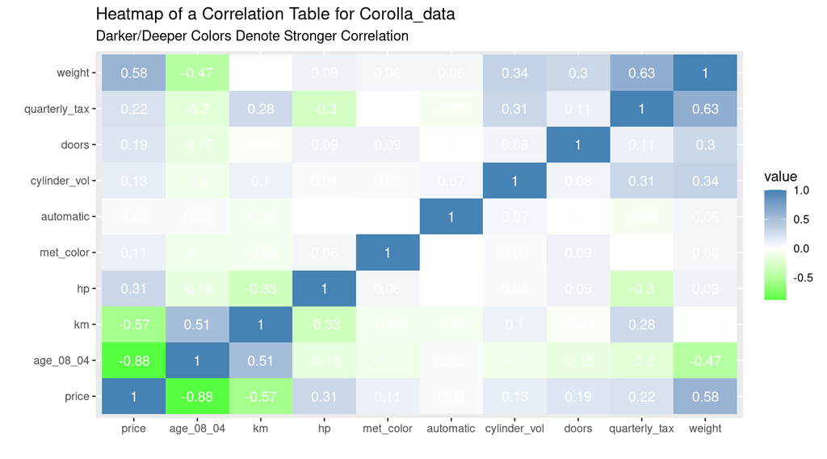

```r
corolla_data %>%
  select(-id) %>%
  select_if(is.numeric) %>%
  cor() %>%
  round(2) %>%
  melt() %>%
  ggplot(aes(x = Var1, y = Var2, fill = value)) +
    geom_tile() +
    geom_text(aes(label = value), color = "white") +
    scale_fill_gradient2(low = "green", high = "steelblue", guide = "colorbar") +
    labs(title = "Heatmap of a Correlation Table for Corolla_data",
         subtitle = "Darker/Deeper Colors Denote Stronger Correlation",
         x = "", y = "")
```

Age and price are the most highly correlated variables in this data set.

## Question 11

```r
corolla_data <- corolla_data %>%
  recipe(~ .) %>%
  step_mutate(automatic = as.factor(automatic),
              met_color = as.factor(met_color)) %>%
  step_dummy(all_of(c("fuel_type", "met_color", "automatic")),
             keep_original_cols = TRUE,
             one_hot = TRUE) %>%
  prep(training = corolla_data) %>%
  bake(new_data = corolla_data)

corolla_data %>%
  head(10) %>%
  kable() %>%
  kable_styling() %>%
  scroll_box(width = "100%", height = "400px")
```

| id | model | price | age_08_04 | km | fuel_type | hp | met_color | automatic | cylinder_vol | doors | quarterly_tax | weight | fuel_type_CNG | fuel_type_Diesel | fuel_type_Petrol | met_color_X0 | met_color_X1 | automatic_X0 | automatic_X1 |
| --- | --- | --- | --- | --- | --- | --- | --- | --- | --- | --- | --- | --- | --- | --- | --- | --- | --- | --- | --- |
| 1 | TOYOTA Corolla 2.0 D4D HATCHB TERRA 2/3-Doors | 13500 | 23 | 46986 | Diesel | 90 | 1 | 0 | 2000 | 3 | 210 | 1165 | 0 | 1 | 0 | 0 | 1 | 1 | 0 |
| 2 | TOYOTA Corolla 2.0 D4D HATCHB TERRA 2/3-Doors | 13750 | 23 | 72937 | Diesel | 90 | 1 | 0 | 2000 | 3 | 210 | 1165 | 0 | 1 | 0 | 0 | 1 | 1 | 0 |
| 3 | TOYOTA Corolla 2.0 D4D HATCHB TERRA 2/3-Doors | 13950 | 24 | 41711 | Diesel | 90 | 1 | 0 | 2000 | 3 | 210 | 1165 | 0 | 1 | 0 | 0 | 1 | 1 | 0 |
| 4 | TOYOTA Corolla 2.0 D4D HATCHB TERRA 2/3-Doors | 14950 | 26 | 48000 | Diesel | 90 | 0 | 0 | 2000 | 3 | 210 | 1165 | 0 | 1 | 0 | 1 | 0 | 1 | 0 |
| 5 | TOYOTA Corolla 2.0 D4D HATCHB SOL 2/3-Doors | 13750 | 30 | 38500 | Diesel | 90 | 0 | 0 | 2000 | 3 | 210 | 1170 | 0 | 1 | 0 | 1 | 0 | 1 | 0 |
| 6 | TOYOTA Corolla 2.0 D4D HATCHB SOL 2/3-Doors | 12950 | 32 | 61000 | Diesel | 90 | 0 | 0 | 2000 | 3 | 210 | 1170 | 0 | 1 | 0 | 1 | 0 | 1 | 0 |
| 7 | TOYOTA Corolla 2.0 D4D 90 3DR TERRA 2/3-Doors | 16900 | 27 | 94612 | Diesel | 90 | 1 | 0 | 2000 | 3 | 210 | 1245 | 0 | 1 | 0 | 0 | 1 | 1 | 0 |
| 8 | TOYOTA Corolla 2.0 D4D 90 3DR TERRA 2/3-Doors | 18600 | 30 | 75889 | Diesel | 90 | 1 | 0 | 2000 | 3 | 210 | 1245 | 0 | 1 | 0 | 0 | 1 | 1 | 0 |
| 9 | TOYOTA Corolla 1800 T SPORT VVT I 2/3-Doors | 21500 | 27 | 19700 | Petrol | 192 | 0 | 0 | 1800 | 3 | 100 | 1185 | 0 | 0 | 1 | 1 | 0 | 1 | 0 |
| 10 | TOYOTA Corolla 1.9 D HATCHB TERRA 2/3-Doors | 12950 | 23 | 71138 | Diesel | 69 | 0 | 0 | 1900 | 3 | 185 | 1105 | 0 | 1 | 0 | 1 | 0 | 1 | 0 |

## Question 12

```r
set.seed(2022)

first_split <- initial_split(corolla_data, prop = 0.5)

training_corolla <- training(first_split)

second_split <- initial_split(testing(first_split), prop = 0.6)

validation_corolla <- training(second_split)
testing_corolla <- testing(second_split)

glimpse(training_corolla)
```

```
## Rows: 718
## Columns: 20
## $ id               <dbl> 229, 826, 711, 777, 706, 478, 124, 234, 1300, 1278, 1…
## $ model            <fct> TOYOTA Corolla 1.4 16V VVT I LIFTB LUNA 4/5-Doors, TO…
## $ price            <dbl> 11690, 9500, 8500, 10950, 8250, 8950, 16350, 11950, 8…
## $ age_08_04        <dbl> 34, 65, 67, 67, 63, 54, 14, 42, 77, 80, 68, 67, 4, 54…
## $ km               <dbl> 65345, 70068, 92922, 77821, 94504, 64000, 40010, 6130…
## $ fuel_type        <fct> Petrol, Petrol, Diesel, Petrol, Petrol, Petrol, Petro…
## $ hp               <dbl> 97, 110, 72, 110, 86, 97, 110, 97, 110, 110, 86, 86, …
## $ met_color        <fct> 1, 1, 1, 1, 1, 1, 1, 1, 0, 1, 1, 1, 1, 1, 1, 1, 1, 0,…
## $ automatic        <fct> 0, 0, 0, 0, 0, 0, 0, 0, 0, 0, 0, 0, 0, 0, 0, 0, 0, 0,…
## $ cylinder_vol     <dbl> 1400, 1600, 2000, 1600, 1300, 1400, 1600, 1400, 1600,…
## $ doors            <dbl> 5, 5, 4, 5, 4, 3, 5, 3, 5, 5, 4, 3, 5, 5, 5, 3, 3, 3,…
## $ quarterly_tax    <dbl> 85, 85, 185, 85, 69, 69, 85, 69, 85, 85, 69, 69, 283,…
## $ weight           <dbl> 1060, 1075, 1100, 1075, 1000, 1025, 1115, 1030, 1075,…
## $ fuel_type_CNG    <dbl> 0, 0, 0, 0, 0, 0, 0, 0, 0, 0, 0, 0, 0, 0, 0, 0, 0, 0,…
## $ fuel_type_Diesel <dbl> 0, 0, 1, 0, 0, 0, 0, 0, 0, 0, 0, 0, 1, 0, 0, 1, 0, 0,…
## $ fuel_type_Petrol <dbl> 1, 1, 0, 1, 1, 1, 1, 1, 1, 1, 1, 1, 0, 1, 1, 0, 1, 1,…
## $ met_color_X0     <dbl> 0, 0, 0, 0, 0, 0, 0, 0, 1, 0, 0, 0, 0, 0, 0, 0, 0, 1,…
## $ met_color_X1     <dbl> 1, 1, 1, 1, 1, 1, 1, 1, 0, 1, 1, 1, 1, 1, 1, 1, 1, 0,…
## $ automatic_X0     <dbl> 1, 1, 1, 1, 1, 1, 1, 1, 1, 1, 1, 1, 1, 1, 1, 1, 1, 1,…
## $ automatic_X1     <dbl> 0, 0, 0, 0, 0, 0, 0, 0, 0, 0, 0, 0, 0, 0, 0, 0, 0, 0,…
```

```r
glimpse(validation_corolla)
```

```
## Rows: 430
## Columns: 20
## $ id               <dbl> 1272, 416, 56, 1306, 1175, 488, 219, 328, 85, 223, 69…
## $ model            <fct> TOYOTA Corolla 1.6 Linea Terra Sd 4/5-Doors, TOYOTA C…
## $ price            <dbl> 8750, 11950, 13250, 8950, 9250, 10500, 10950, 10950, …
## $ age_08_04        <dbl> 78, 51, 32, 72, 74, 50, 41, 42, 25, 44, 67, 57, 77, 5…
## $ km               <dbl> 75226, 98040, 45725, 71054, 96000, 62280, 75697, 3362…
## $ fuel_type        <fct> Petrol, Petrol, Petrol, Petrol, Petrol, Petrol, Petro…
## $ hp               <dbl> 110, 110, 110, 86, 110, 97, 97, 97, 97, 110, 110, 110…
## $ met_color        <fct> 0, 0, 1, 0, 1, 1, 1, 1, 1, 1, 1, 0, 1, 0, 1, 0, 1, 1,…
## $ automatic        <fct> 0, 0, 0, 1, 0, 0, 0, 0, 0, 0, 0, 0, 0, 0, 0, 0, 0, 0,…
## $ cylinder_vol     <dbl> 1600, 1600, 1600, 1300, 1600, 1400, 1400, 1400, 1400,…
## $ doors            <dbl> 4, 5, 5, 3, 5, 5, 3, 3, 5, 5, 5, 5, 5, 3, 5, 5, 3, 3,…
## $ quarterly_tax    <dbl> 69, 85, 85, 69, 85, 85, 69, 69, 85, 163, 85, 85, 69, …
## $ weight           <dbl> 1035, 1080, 1075, 1045, 1085, 1060, 1025, 1025, 1110,…
## $ fuel_type_CNG    <dbl> 0, 0, 0, 0, 0, 0, 0, 0, 0, 0, 0, 0, 0, 0, 0, 0, 0, 0,…
## $ fuel_type_Diesel <dbl> 0, 0, 0, 0, 0, 0, 0, 0, 0, 0, 0, 0, 0, 0, 0, 0, 0, 0,…
## $ fuel_type_Petrol <dbl> 1, 1, 1, 1, 1, 1, 1, 1, 1, 1, 1, 1, 1, 1, 1, 1, 1, 1,…
## $ met_color_X0     <dbl> 1, 1, 0, 1, 0, 0, 0, 0, 0, 0, 0, 1, 0, 1, 0, 1, 0, 0,…
## $ met_color_X1     <dbl> 0, 0, 1, 0, 1, 1, 1, 1, 1, 1, 1, 0, 1, 0, 1, 0, 1, 1,…
## $ automatic_X0     <dbl> 1, 1, 1, 0, 1, 1, 1, 1, 1, 1, 1, 1, 1, 1, 1, 1, 1, 1,…
## $ automatic_X1     <dbl> 0, 0, 0, 1, 0, 0, 0, 0, 0, 0, 0, 0, 0, 0, 0, 0, 0, 0,…
```

```r
glimpse(testing_corolla)
```

```
## Rows: 288
## Columns: 20
## $ id               <dbl> 6, 12, 24, 25, 27, 28, 30, 32, 34, 37, 42, 45, 49, 62…
## $ model            <fct> TOYOTA Corolla 2.0 D4D HATCHB SOL 2/3-Doors, TOYOTA C…
## $ price            <dbl> 12950, 19950, 16950, 16250, 17495, 15750, 17950, 1575…
## $ age_08_04        <dbl> 32, 22, 28, 29, 27, 29, 30, 22, 26, 25, 27, 22, 22, 2…
## $ km               <dbl> 61000, 43610, 32220, 25813, 34545, 41415, 11090, 3519…
## $ fuel_type        <fct> Diesel, Petrol, Petrol, Petrol, Petrol, Petrol, Petro…
## $ hp               <dbl> 90, 192, 110, 110, 110, 110, 110, 97, 97, 97, 97, 90,…
## $ met_color        <fct> 0, 0, 1, 1, 1, 1, 1, 1, 1, 0, 1, 0, 1, 0, 1, 1, 1, 1,…
## $ automatic        <fct> 0, 0, 0, 0, 0, 0, 0, 0, 0, 0, 0, 0, 0, 0, 0, 0, 0, 0,…
## $ cylinder_vol     <dbl> 2000, 1800, 1600, 1600, 1600, 1600, 1600, 1400, 1400,…
## $ doors            <dbl> 3, 3, 3, 3, 3, 3, 3, 3, 3, 3, 3, 5, 5, 5, 5, 5, 5, 5,…
## $ quarterly_tax    <dbl> 210, 100, 85, 85, 85, 85, 85, 85, 85, 85, 85, 234, 23…
## $ weight           <dbl> 1170, 1185, 1120, 1120, 1120, 1120, 1120, 1100, 1100,…
## $ fuel_type_CNG    <dbl> 0, 0, 0, 0, 0, 0, 0, 0, 0, 0, 0, 0, 0, 0, 0, 0, 0, 0,…
## $ fuel_type_Diesel <dbl> 1, 0, 0, 0, 0, 0, 0, 0, 0, 0, 0, 1, 1, 0, 0, 0, 0, 0,…
## $ fuel_type_Petrol <dbl> 0, 1, 1, 1, 1, 1, 1, 1, 1, 1, 1, 0, 0, 1, 1, 1, 1, 1,…
## $ met_color_X0     <dbl> 1, 1, 0, 0, 0, 0, 0, 0, 0, 1, 0, 1, 0, 1, 0, 0, 0, 0,…
## $ met_color_X1     <dbl> 0, 0, 1, 1, 1, 1, 1, 1, 1, 0, 1, 0, 1, 0, 1, 1, 1, 1,…
## $ automatic_X0     <dbl> 1, 1, 1, 1, 1, 1, 1, 1, 1, 1, 1, 1, 1, 1, 1, 1, 1, 1,…
## $ automatic_X1     <dbl> 0, 0, 0, 0, 0, 0, 0, 0, 0, 0, 0, 0, 0, 0, 0, 0, 0, 0,…
```

In modeling, partition data is a common practice to ensure the most efficient and accurate results. When partitioning, the data is divided into three categories: train, validation, and test. First, the training data, which is usually 50% or more of the total data, is used by the model to learn the data. During this step, the model is understanding the mathematical relationship between features and target variables. Second, the validation data, which is usually 20% of the total data, is used to tune the weights of the model to prevent over fitting and for the model architect to change any hyper parameters. Finally, the test data, which is usually 20% of the total data, is used to evaluate the accuracy of the model. During this step the architect of the model asses its performance.

# Project Log

- Use the following website for scale_x_date() function: https://ggplot2.tidyverse.org/reference/scale_date.html
- Used the following website for scale_fill_manual() function: https://ggplot2.tidyverse.org/reference/scale_manual.html
- Used the following website for across() function: https://dplyr.tidyverse.org/reference/across.html
- Used the following website for everything() function: https://tidyselect.r-lib.org/reference/everything.html
- Used the following website for grepl() function: https://campus.datacamp.com/courses/intermediate-r/chapter-5-utilities?ex=8

# Honor Code

I have neither given nor received unauthorized aid on this work.

Alex Wolff, 2024-04-13